# Codebook for tidyData.txt

Autogenerated data summary from dataMaid and variable descriptions added by the author

2020-07-16 14:00:57

# Data report overview

The dataset examined has the following dimensions:

| Feature | Result |
| --- | --- |
| Number of observations | 11880 |
| Number of variables | 7 |

# Codebook summary table

[output not shown]

# Variable list

## Subject

| Feature | Result |
| --- | --- |
| Variable type | integer |
| Number of missing obs. | 0 (0 %) |
| Number of unique values | 30 |
| Median | 15.5 |
| 1st and 3rd quartiles | 8; 23 |
| Min. and max. | 1; 30 |

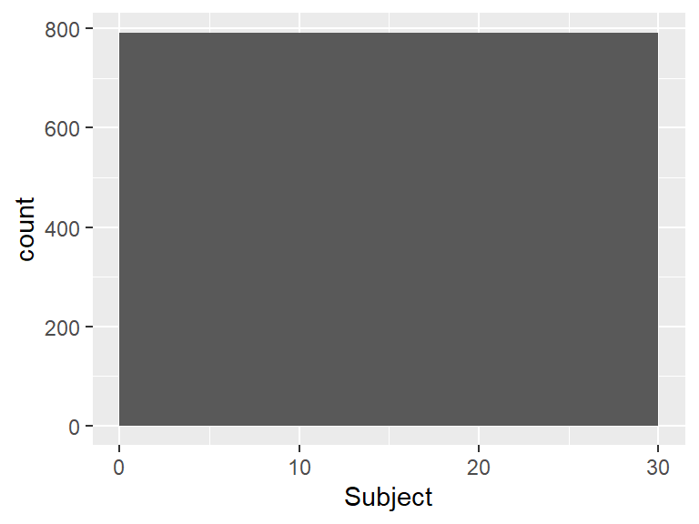

## Activity

| Feature | Result |
| --- | --- |
| Variable type | factor |
| Number of missing obs. | 0 (0 %) |
| Number of unique values | 6 |
| Mode | “WALKING” |
| Reference category | WALKING |

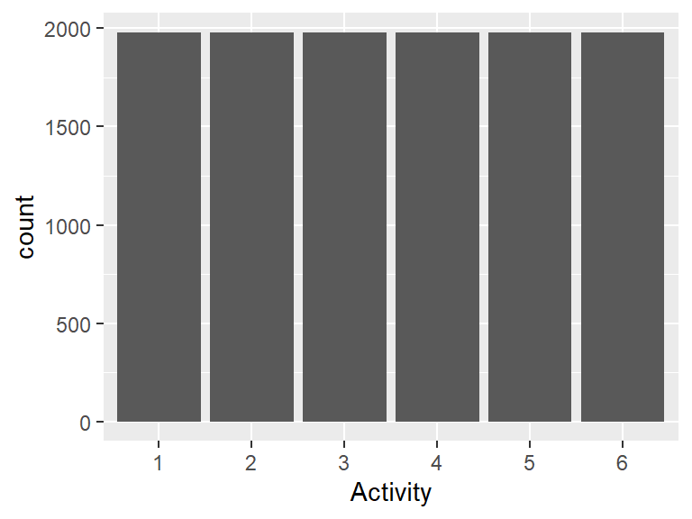

- Observed factor levels: 1-"WALKING", 2-"WALKING UPSTAIRS", 3-"WALKING DOWNSTAIRS", 4-"SITTING", 5-"STANDING", 6-"LAYING".

## Domain

| Feature | Result |
| --- | --- |
| Variable type | character |
| Number of missing obs. | 0 (0 %) |
| Number of unique values | 2 |
| Mode | “Time” |

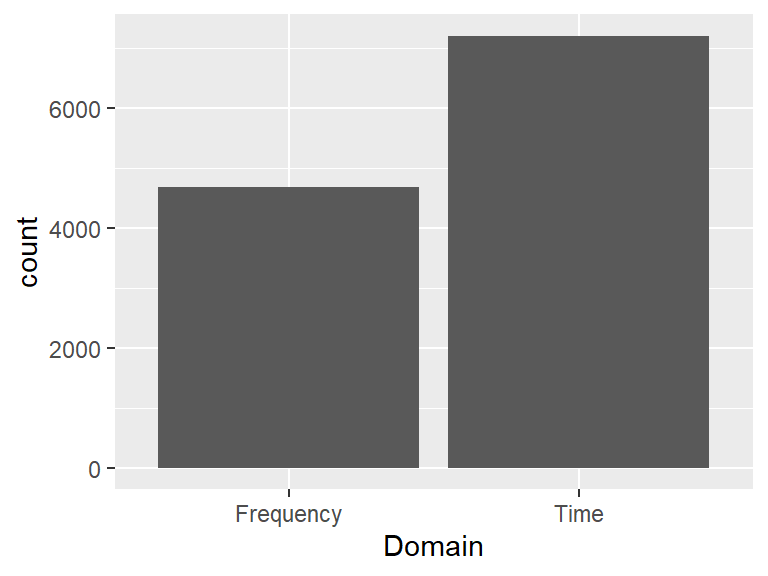

- Observed factor levels: "Frequency", "Time".

## Motion

| Feature | Result |
| --- | --- |
| Variable type | character |
| Number of missing obs. | 0 (0 %) |
| Number of unique values | 2 |
| Mode | “Body” |

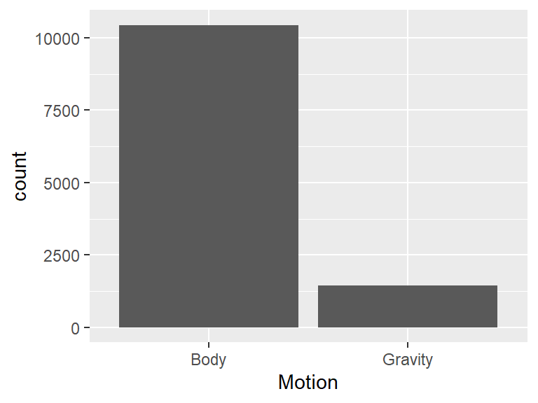

- Observed factor levels: "Body", "Gravity".

## Sensor

| Feature | Result |
| --- | --- |
| Variable type | character |
| Number of missing obs. | 0 (0 %) |
| Number of unique values | 8 |
| Mode | “Accelerometer” |

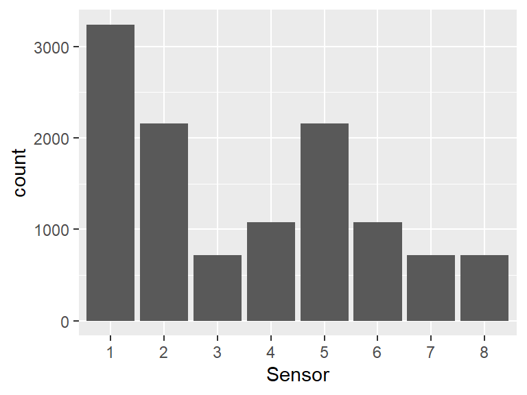

- Observed factor levels: 1-"Accelerometer", 2-"Accelerometer Jerk", 3-"Accelerometer Jerk Magnitude", 4-"Accelerometer Magnitude", 5-"Gyroscope", 6-"Gyroscope Jerk", 7-"Gyroscope Jerk Magnitude", 8-"Gyroscope Magnitude".
- Note: In the "Sensor" column you may encounter the words "Jerk" and/or "Magnitude". The word "Jerk" refers to Jerk signals obtained from the body linear acceleration and angular velocity derived in time. The word "Magnitude" refers to the magnitudes of the three-dimensional signals calculated using the Euclidean norm.

## Values

| Feature | Result |
| --- | --- |
| Variable type | character |
| Number of missing obs. | 0 (0 %) |
| Number of unique values | 8 |
| Mode | “Mean” |

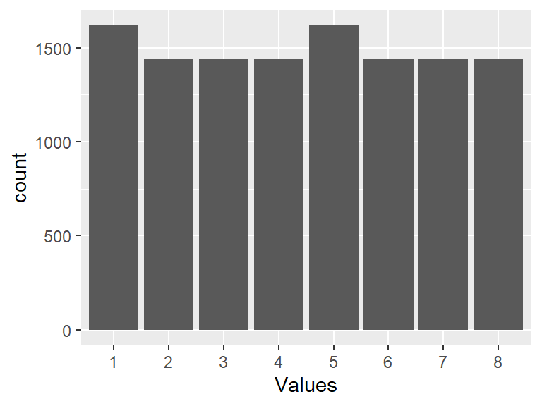

- Observed factor levels: 1-"Mean", 2-"Mean in X direction", 3-"Mean in Y direction", 4-"Mean in Z direction", 5-"std", 6-"std in X direction", 7-"std in Y direction", 8-"std in Z direction".

## Average

| Feature | Result |
| --- | --- |
| Variable type | numeric |
| Number of missing obs. | 0 (0 %) |
| Number of unique values | 11520 |
| Median | -0.47 |
| 1st and 3rd quartiles | -0.96; -0.08 |
| Min. and max. | -1; 0.97 |

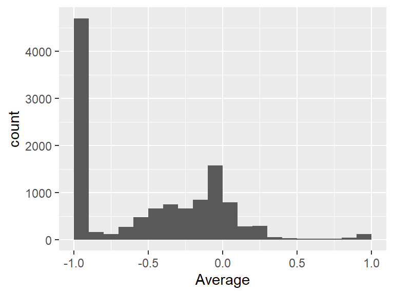

Report generation information:

- Created by: Angie Marchany-Rivera.
- Report creation time: Thu Jul 16 2020 14:00:58
- Report was run from directory: `C:/Users/angie/Desktop/GettingAndCleaningDataProject`
- dataMaid v1.4.0 [Pkg: 2019-12-10 from CRAN (R 4.0.2)]
- R version 4.0.0 (2020-04-24).
- Platform: x86_64-w64-mingw32/x64 (64-bit)(Windows 10 x64 (build 18363)).
- Function call: `dataMaid::makeDataReport(data = tidyData, mode = c("summarize", "visualize", "check"), smartNum = FALSE, file = "codebook_tidyData.Rmd", checks = list(character = "showAllFactorLevels", factor = "showAllFactorLevels", labelled = "showAllFactorLevels", haven_labelled = "showAllFactorLevels", numeric = NULL, integer = NULL, logical = NULL, Date = NULL), listChecks = FALSE, maxProbVals = Inf, codebook = TRUE, reportTitle = "Codebook for tidyData")`